# 进阶练习：K-means 聚类

第一次上机的选做进阶内容

Author

Guangchuang Yu  
School of Basic Medical Sciences, Southern Medical University

Published

October 12, 2026

**Note这份材料的位置**

第一次上机的主线是 R 语言与数据可视化：认识数据结构、取子集、用管道汇总、把图按图形语法画出来。**这里做的是它的进阶部分**——把”哪些样本像哪些样本”这件事交给算法，而不是靠你手上的分组标签。

做之前请先完成 r-vis 的第 1–6 节；本页用到的 `apply` 家族、管道、`ggplot2` 与 PCA 都在那边练过（那边用的是 `airquality`/`mpg`，本页换成 `iris`——**同一套技能，换一份数据**）。

K-means 要回答的是：**没有标签的时候，数据能不能自己站队？** 这正是第 5 讲单细胞聚类的思想雏形——那边换成了 Louvain 社区发现，但”先定分组数、再看结果稳不稳”的麻烦是一样的。

用到的数据是 `iris` 的前四列（150 朵花的四个形态测量），物种标签放在一边，只当”标准答案”，用来检查算法做得怎么样。

```r
library(yulab.utils)
pload(ggplot2)
pload(dplyr)
pload(tidyr)

data(iris)
d <- iris[, 1:4]          # 只用测量值，先把 Species 放到一边
head(d)
```

```
  Sepal.Length Sepal.Width Petal.Length Petal.Width
1          5.1         3.5          1.4         0.2
2          4.9         3.0          1.4         0.2
3          4.7         3.2          1.3         0.2
4          4.6         3.1          1.5         0.2
5          5.0         3.6          1.4         0.2
6          5.4         3.9          1.7         0.4
```

```r
table(iris$Species)
```

```
    setosa versicolor  virginica
        50         50         50
```

## 1 算法步骤

1. 选择聚类数 $k$
2. 随机选择 $k$ 个初始中心
3. 把每个样本分配给最近的中心
4. 把中心更新为各簇的均值
5. 重复 3–4 直到不再变化（或达到迭代上限）

第 2 步是”随机”的，所以**同一个 $k$ 跑两次结果可能不同**。这是 K-means 最实际的一个坑，`set.seed()` 与 `nstart` 都是为了对付它。

```r
set.seed(123)
km <- kmeans(d, centers = 3, nstart = 25)
km
```

```
K-means clustering with 3 clusters of sizes 50, 62, 38

Cluster means:
  Sepal.Length Sepal.Width Petal.Length Petal.Width
1     5.006000    3.428000     1.462000    0.246000
2     5.901613    2.748387     4.393548    1.433871
3     6.850000    3.073684     5.742105    2.071053

Clustering vector:
  [1] 1 1 1 1 1 1 1 1 1 1 1 1 1 1 1 1 1 1 1 1 1 1 1 1 1 1 1 1 1 1 1 1 1 1 1 1 1
 [38] 1 1 1 1 1 1 1 1 1 1 1 1 1 2 2 3 2 2 2 2 2 2 2 2 2 2 2 2 2 2 2 2 2 2 2 2 2
 [75] 2 2 2 3 2 2 2 2 2 2 2 2 2 2 2 2 2 2 2 2 2 2 2 2 2 2 3 2 3 3 3 3 2 3 3 3 3
[112] 3 3 2 2 3 3 3 3 2 3 2 3 2 3 3 2 2 3 3 3 3 3 2 3 3 3 3 2 3 3 3 2 3 3 3 2 3
[149] 3 2

Within cluster sum of squares by cluster:
[1] 15.15100 39.82097 23.87947
 (between_SS / total_SS =  88.4 %)

Available components:

[1] "cluster"      "centers"      "totss"        "withinss"     "tot.withinss"
[6] "betweenss"    "size"         "iter"         "ifault"
```

`nstart = 25` 的意思是”用 25 组不同的随机初始中心各跑一遍，留下组内平方和最小的那次”。它不改变算法，只是让结果别太看运气。

## 2 和真实物种对一对

```r
table(真实物种 = iris$Species, 聚类 = km$cluster)
```

```
            聚类
真实物种  1  2  3
  setosa     50  0  0
  versicolor  0 48  2
  virginica   0 14 36
```

setosa 那一行干干净净地落进同一簇；**versicolor 与 virginica 被切开了**。原因在数据本身：这两个物种在萼片长度与宽度上大量重叠，K-means 只能按”离中心最近”来分，分不开它们。这不是代码写错了，是**方法的前提与数据结构不匹配**——第 2 讲那句”图选错了不是不美观，是信息被丢掉了”，在这里就是”方法选错了不是不准，是问题本身没被回答”。

## 3 画出来看

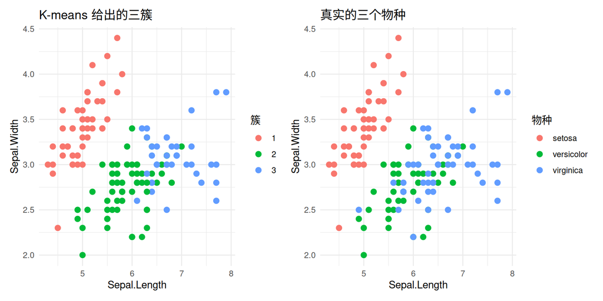

```r
clust <- d
clust$cluster <- factor(km$cluster)
clust$species <- iris$Species

p1 <- ggplot(clust, aes(Sepal.Length, Sepal.Width, color = cluster)) +
    geom_point(size = 2.5) +
    labs(title = "K-means 给出的三簇", color = "簇") +
    theme_minimal()

p2 <- ggplot(clust, aes(Sepal.Length, Sepal.Width, color = species)) +
    geom_point(size = 2.5) +
    labs(title = "真实的三个物种", color = "物种") +
    theme_minimal()

aplot::plot_list(p1, p2, ncol = 2)
```

左边是算法看到的，右边是事实。两张图用**同一份数据、同一套映射**，只换了颜色那一列——这就是图形语法讲过的”数据与映射分开写”的用处：换一个变量看同一批数据，成本是一行代码。

**Tip动手**

在左边的图上叠加中心点（`geom_point(data = 中心坐标, shape = 4, size = 4)`），中心坐标可以从 `km$centers` 取。做完再回答：中心点落在哪个位置，才能把 versicolor 和 virginica 分开？

## 4 肘部法则：$k$ 怎么定

组内平方和（WSS, within-cluster sum of squares）随 $k$ 增大只会下降——$k$ 等于样本数时它一定是 0。所以”WSS 最小”这个标准没用，要找的是**曲线拐弯的地方**（肘部）。

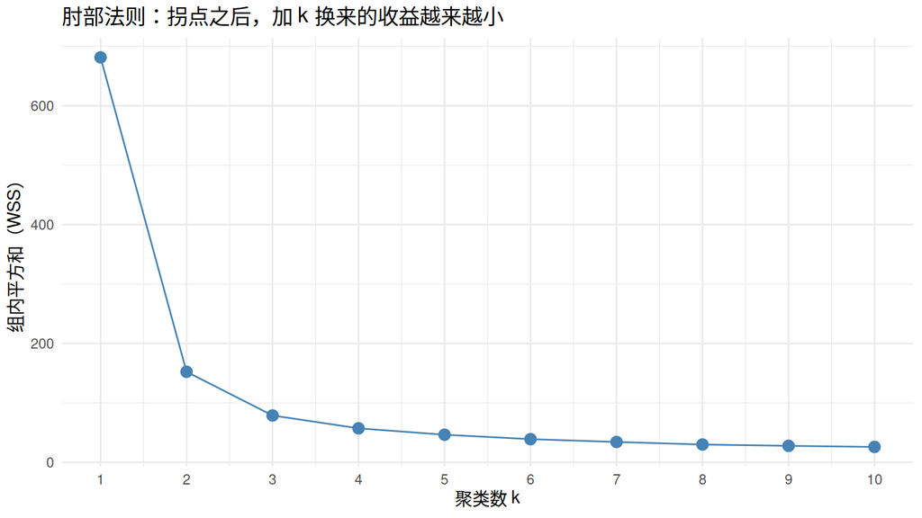

```r
set.seed(123)
wss <- sapply(1:10, function(k) kmeans(d, centers = k, nstart = 25)$tot.withinss)

ggplot(data.frame(k = 1:10, wss = wss), aes(k, wss)) +
    geom_line(color = "steelblue") +
    geom_point(size = 3, color = "steelblue") +
    scale_x_continuous(breaks = 1:10) +
    labs(x = "聚类数 k", y = "组内平方和（WSS）",
         title = "肘部法则：拐点之后，加 k 换来的收益越来越小") +
    theme_minimal()
```

```r
round(wss, 2)
```

```
 [1] 681.37 152.35  78.85  57.23  46.45  39.04  34.30  29.99  27.79  25.96
```

```r
wss[1] - wss[2]      # k=1 → 2 的下降
```

```
[1] 529.0226
```

```r
wss[2] - wss[3]      # k=2 → 3 的下降
```

```
[1] 73.49651
```

```r
wss[3] - wss[4]      # k=3 → 4 的下降
```

```
[1] 21.62297
```

**Warning这里有一个真实发生过的错误**

如果先把聚类结果写回数据框、再拿去算肘部曲线，比如：

```r
# 错误示范：不要这样做
d2 <- d
d2$cluster <- as.factor(km$cluster)   # 多了一列因子
wss_bad <- sapply(1:10, function(k) kmeans(d2, centers = k, nstart = 25)$tot.withinss)
```

`d2` 比 `d` 多了一列 `cluster`。因子在 `kmeans()` 里会被当成整数参与距离计算，于是：

- $k=1$ 时的组内平方和从 **681.37** 变成 **768.41**（我在这里用 `set.seed(123)` 复算过；具体数字随随机种子变化，但一定偏大）；
- **它不会报错**。唯一的问题是曲线整体被抬高，而”拐点在哪”这个判断会跟着漂。

这类错误比语法错误危险得多：语法错了你会改，数字错了你不会。**第一件事永远是 `str(d)` 或 `dim(d)`，确认喂给算法的到底是哪几列。**

**Tip动手**

1. 跑一遍上面的”错误示范”，把两条曲线画在同一张图上（`geom_line()` 两次，或把两个向量 `pivot_longer()` 之后分面），并解释差在哪。
2. 换一个随机种子（`set.seed(1)`、`set.seed(2024)`）各算一次 $k=3$ 的聚类，比较分组是否一致（提示：`table()` 两次结果）。

## 5 换一个视角：先降维再聚类

`iris` 只有四列，可以直接聚类；但真实数据动辄几百上千列，距离会被大量噪声维度主导。常见做法是先做 PCA 降维再聚类。

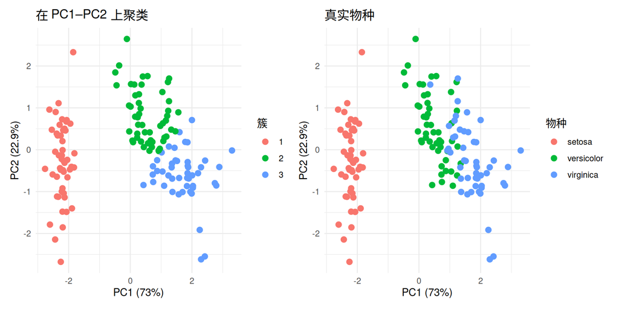

```r
pca <- prcomp(d, scale. = TRUE)
pc <- as.data.frame(pca$x[, 1:2])
var_pct <- round(100 * pca$sdev^2 / sum(pca$sdev^2), 1)

set.seed(123)
km_pc <- kmeans(pc, centers = 3, nstart = 25)
pc$cluster <- factor(km_pc$cluster)
pc$species <- iris$Species

g1 <- ggplot(pc, aes(PC1, PC2, color = cluster)) + geom_point(size = 2.5) +
    labs(title = "在 PC1–PC2 上聚类", color = "簇",
         x = paste0("PC1 (", var_pct[1], "%)"), y = paste0("PC2 (", var_pct[2], "%)")) +
    theme_minimal()
g2 <- ggplot(pc, aes(PC1, PC2, color = species)) + geom_point(size = 2.5) +
    labs(title = "真实物种", color = "物种",
         x = paste0("PC1 (", var_pct[1], "%)"), y = paste0("PC2 (", var_pct[2], "%)")) +
    theme_minimal()

aplot::plot_list(g1, g2, ncol = 2)
```

```r
table(真实物种 = iris$Species, 降维后聚类 = km_pc$cluster)
```

```
            降维后聚类
真实物种  1  2  3
  setosa     50  0  0
  versicolor  0 39 11
  virginica   0 14 36
```

前两个主成分解释了绝大部分形态差异，setosa 与另外两个物种被彻底分开。**但 versicolor 与 virginica 仍然重叠**——降维能让结构看得见，不能把不存在于这四列测量里的差异变出来。

## 6 稳定性：结果能重来吗

```r
stability <- lapply(1:3, function(s) {
    set.seed(s)
    kmeans(d, centers = 3, nstart = 1)$cluster   # 故意只用 1 组初始中心
})
sapply(stability, function(x) length(unique(x)))
```

```
[1] 3 3 3
```

```r
table(聚类1 = stability[[1]], 聚类2 = stability[[2]])
```

```
     聚类2
聚类1  1  2  3
    1 62  0  0
    2  0  0 38
    3  0 50  0
```

**Tip动手**

1. 把 `nstart` 依次设为 1、5、25、50，各跑 3 次，统计三次结果中同一朵花被分到同一簇的比例。
2. 画一条 `nstart` 与”三次结果一致率”的曲线，说明你从哪一个值开始认为结果稳定了。

## 8 小结

- K-means 是**无监督**方法：它不知道 `Species` 这一列，所以你也不能用”准确率”来评价它；
- $k$ 要自己定，肘部法则是经验判据，不是定理；
- 结果依赖随机初始，`set.seed()` 与 `nstart` 是必写项；
- **喂进去的数据决定它能看到什么**：多一列因子会让曲线整体偏移且不报错；先降维能去噪声，但变不出不存在的差异。